# Assignment #4

# 6:

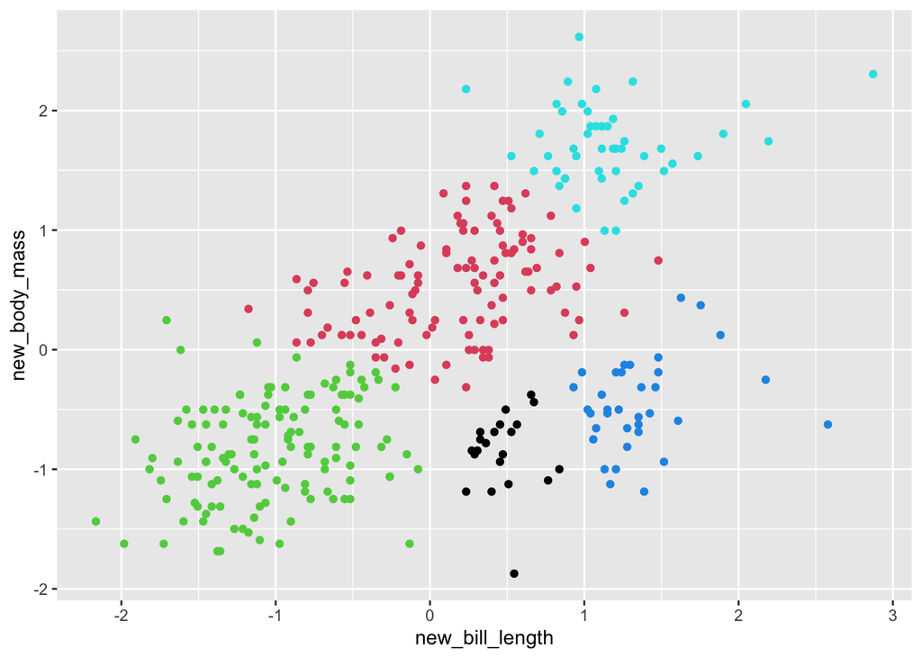

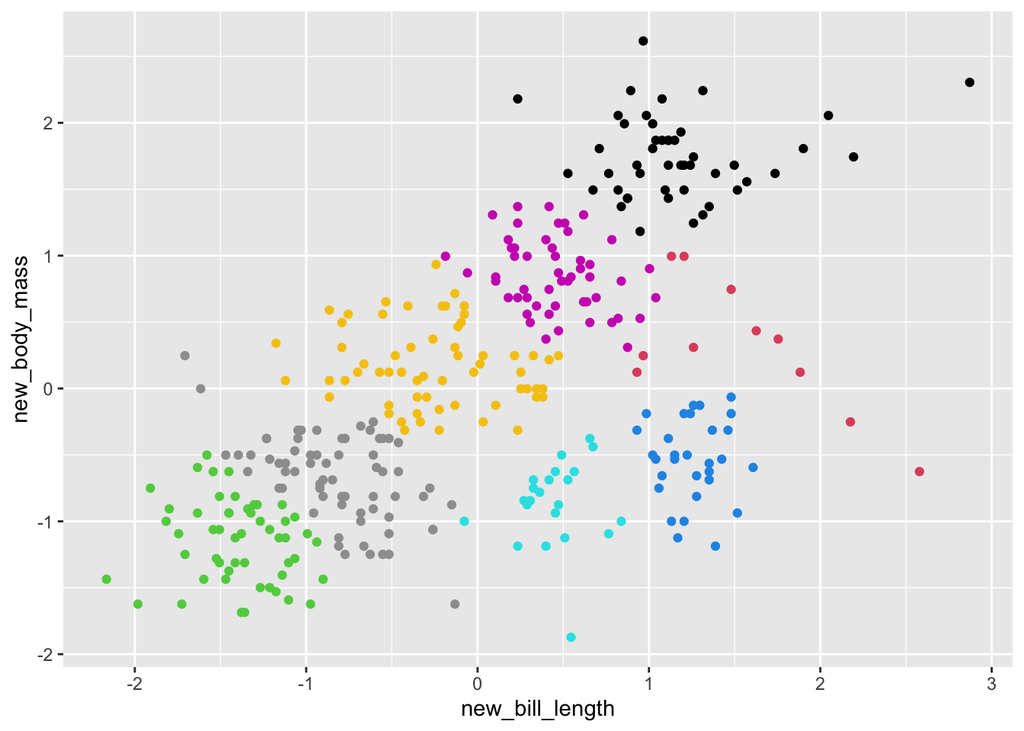

# 7:

This is a dataset that takes the names for babies registered in each year by their SSN and notes how many babies have been given the same first name. These are only for names that have been used more than 5 times between 1880 and 2017. Below is the summary information for the number of times each name has been used. The mean is worthy of being noted, as it is very different from the quantile information, which means that is greatly skewed by the values in the highest 25% of names. These are probably by the very common names, like the ones with over 6,000 - 7,000 appearances.

```
## # A tibble: 1,924,665 × 5
##     year sex   name          n   prop
##    <dbl> <chr> <chr>     <int>  <dbl>
##  1  1880 F     Mary       7065 0.0724
##  2  1880 F     Anna       2604 0.0267
##  3  1880 F     Emma       2003 0.0205
##  4  1880 F     Elizabeth  1939 0.0199
##  5  1880 F     Minnie     1746 0.0179
##  6  1880 F     Margaret   1578 0.0162
##  7  1880 F     Ida        1472 0.0151
##  8  1880 F     Alice      1414 0.0145
##  9  1880 F     Bertha     1320 0.0135
## 10  1880 F     Sarah      1288 0.0132
## # … with 1,924,655 more rows
```

```
##    Min. 1st Qu.  Median    Mean 3rd Qu.    Max.
##     5.0     7.0    12.0   180.9    32.0 99686.0
```

# 8:

# 9:

```
## # A tibble: 6 × 20,878
## # Groups:   year [6]
##    year   Mary   Anna   Emma Elizabeth Minnie Margaret    Ida  Alice Bertha
##   <dbl>  <dbl>  <dbl>  <dbl>     <dbl>  <dbl>    <dbl>  <dbl>  <dbl>  <dbl>
## 1  1880 0.0724 0.0267 0.0205    0.0199 0.0179   0.0162 0.0151 0.0145 0.0135
## 2  1881 0.0700 0.0273 0.0206    0.0187 0.0167   0.0168 0.0146 0.0132 0.0134
## 3  1882 0.0704 0.0272 0.0199    0.0189 0.0173   0.0157 0.0145 0.0133 0.0130
## 4  1883 0.0667 0.0275 0.0197    0.0188 0.0170   0.0157 0.0136 0.0124 0.0140
## 5  1884 0.0670 0.0281 0.0188    0.0185 0.0163   0.0156 0.0137 0.0126 0.0130
## 6  1885 0.0643 0.0281 0.0192    0.0182 0.0153   0.0155 0.0131 0.0118 0.0131
## # … with 20,868 more variables: Sarah <dbl>, Annie <dbl>, Clara <dbl>,
## #   Ella <dbl>, Florence <dbl>, Cora <dbl>, Martha <dbl>, Laura <dbl>,
## #   Nellie <dbl>, Grace <dbl>, Carrie <dbl>, Maude <dbl>, Mabel <dbl>,
## #   Bessie <dbl>, Jennie <dbl>, Gertrude <dbl>, Julia <dbl>, Hattie <dbl>,
## #   Edith <dbl>, Mattie <dbl>, Rose <dbl>, Catherine <dbl>, Lillian <dbl>,
## #   Ada <dbl>, Lillie <dbl>, Helen <dbl>, Jessie <dbl>, Louise <dbl>,
## #   Ethel <dbl>, Lula <dbl>, Eva <dbl>, Frances <dbl>, Lena <dbl>, …
```

# 12:

```
## $names
## [1] "sdev"     "rotation" "center"   "scale"    "x"
##
## $class
## [1] "prcomp"
```

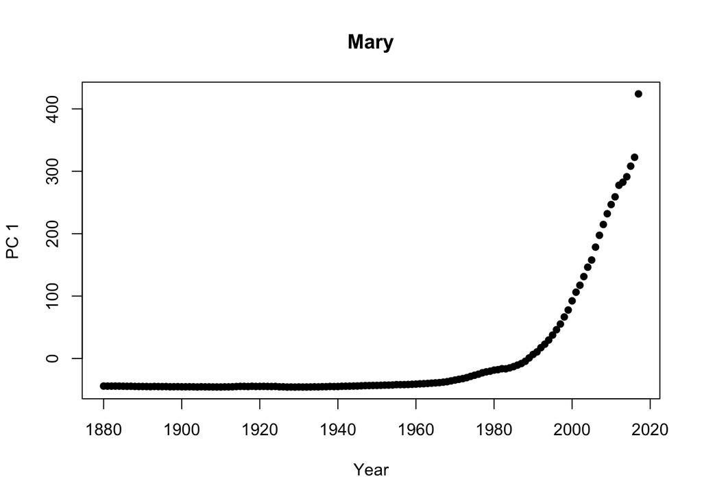

[figure not shown]

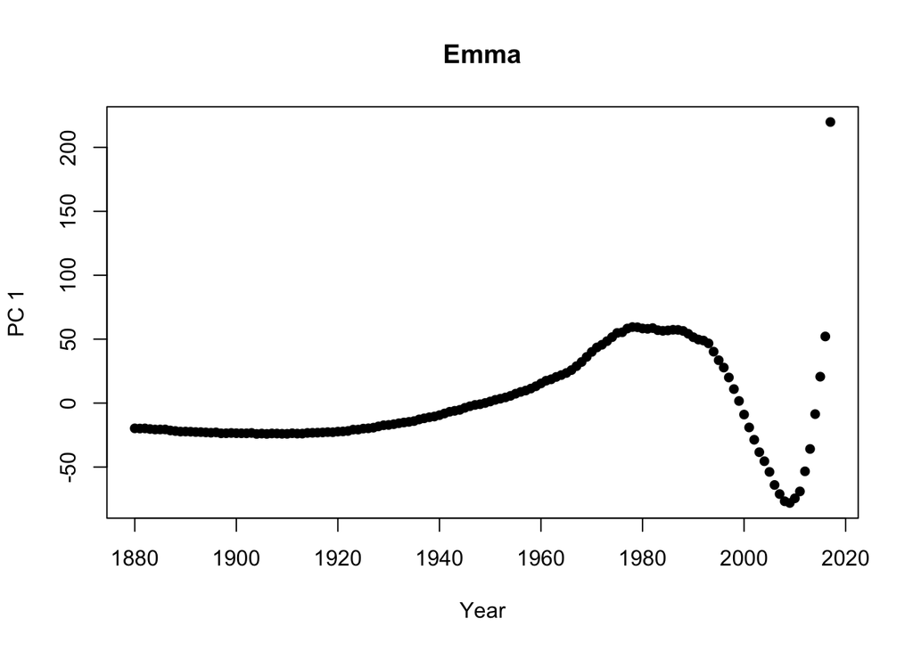

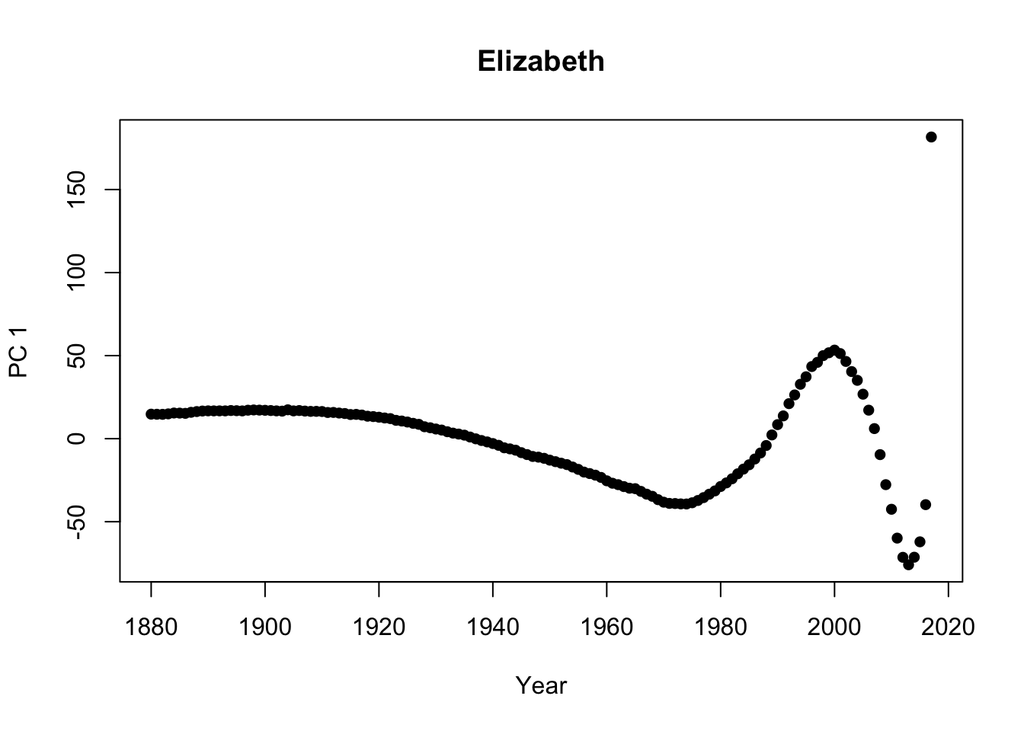

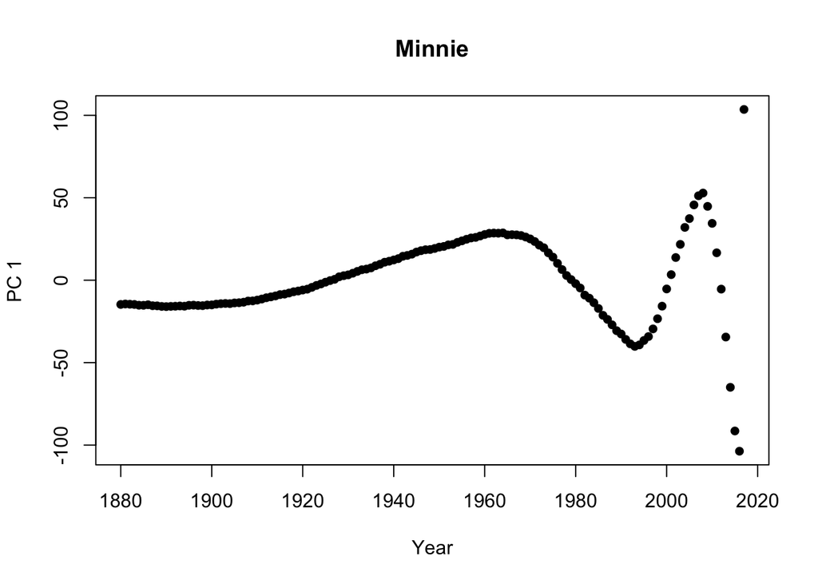

# Acknowledgements:

I asked Daniel Wallace for help in terms of some code in questions 5 and 9.

# Appendix

```r
knitr::opts_chunk$set(echo = FALSE)
library(palmerpenguins)
library(tidyverse)
library(ggplot2)
library("kernlab")
library(babynames)
summary(penguins)
avai_id = which((!is.na(penguins$bill_length_mm)))
pingu = penguins[avai_id,c("species", "island", "bill_length_mm", "bill_depth_mm",
                           "flipper_length_mm", "body_mass_g", "sex", "year")]
summary(pingu)
ggplot(data=pingu, mapping=aes(x=bill_length_mm, y=body_mass_g, color = species)) +
  geom_point()
spec.cluster<-pingu %>% select(bill_length_mm, body_mass_g) %>% as.matrix() %>% specc(centers=3)
ggplot(data=pingu, mapping=aes(x=bill_length_mm, y=body_mass_g)) +
  geom_point(color = spec.cluster)
pingu$new_bill_length = scale(pingu$bill_length_mm)
pingu$new_body_mass = scale(pingu$body_mass_g)
spec.cluster1<-pingu %>% select(new_bill_length, new_body_mass) %>% as.matrix() %>% specc(centers=3)
ggplot(data=pingu, mapping=aes(x=new_bill_length, y=new_body_mass)) +
  geom_point(color = spec.cluster1)
pingu.k3<- pingu %>% select(new_bill_length, new_body_mass) %>% as.matrix() %>% kmeans(centers=3)

ck3 <- pingu.k3$cluster

ggplot(pingu,aes(x=new_bill_length, y=new_body_mass,colour=ck3)) +
  geom_point() +
  theme(legend.position = "none")

spec.cluster2<-pingu %>% select(new_bill_length, new_body_mass) %>% as.matrix() %>% specc(centers=5)
ggplot(data=pingu, mapping=aes(x=new_bill_length, y=new_body_mass)) +
  geom_point(color = spec.cluster2)

spec.cluster3<-pingu %>% select(new_bill_length, new_body_mass) %>% as.matrix() %>% specc(centers=8)
ggplot(data=pingu, mapping=aes(x=new_bill_length, y=new_body_mass)) +
  geom_point(color = spec.cluster3)
babynames
summary(babynames$n)
baby1 = filter(babynames, n >= 500, year == 2017)
#male
babynames.pre1 <- babynames %>% filter(sex == "M")
baby.pre1.5 <- babynames %>% filter(year == 2017)
babynames.pre2 <- babynames.pre1 %>% filter(name %in% baby.pre1.5$name)
babynames.pre3 <- babynames.pre2[,c(-2,-4)]


babynames.male <- babynames.pre3 %>%
              group_by(year) %>%
              pivot_wider(names_from = name,
                          values_from = prop,values_fill=0)
#female
babynames.pre1 <- babynames %>% filter(sex == "F")
baby.pre1.5 <- babynames %>% filter(year == 2017)
babynames.pre2 <- babynames.pre1 %>% filter(name %in% baby.pre1.5$name)
babynames.pre3 <- babynames.pre2[,c(-2,-4)]


babynames.female <- babynames.pre3 %>%
              group_by(year) %>%
              pivot_wider(names_from = name,
                          values_from = prop,values_fill=0)
head(babynames.female)
pc <- prcomp(babynames.female,
             center = TRUE,
            scale. = TRUE)
attributes(pc)
plot(x=babynames.female$year,y=pc$x[,1], pch=16,xlab="Year", ylab="PC 1", main = "Mary")
plot(x=babynames.female$year,y=pc$x[,2], pch=16,xlab="Year", ylab="PC 1", main = "Anna")
plot(x=babynames.female$year,y=pc$x[,3], pch=16,xlab="Year", ylab="PC 1", main = "Emma")
plot(x=babynames.female$year,y=pc$x[,4], pch=16,xlab="Year", ylab="PC 1", main = "Elizabeth")
plot(x=babynames.female$year,y=pc$x[,5], pch=16,xlab="Year", ylab="PC 1", main = "Minnie")
```